# Draft Helper

[figure not shown]

# Given Units

## Eirika

The princess of the kingdom of Renais. She’s elegant and kind.

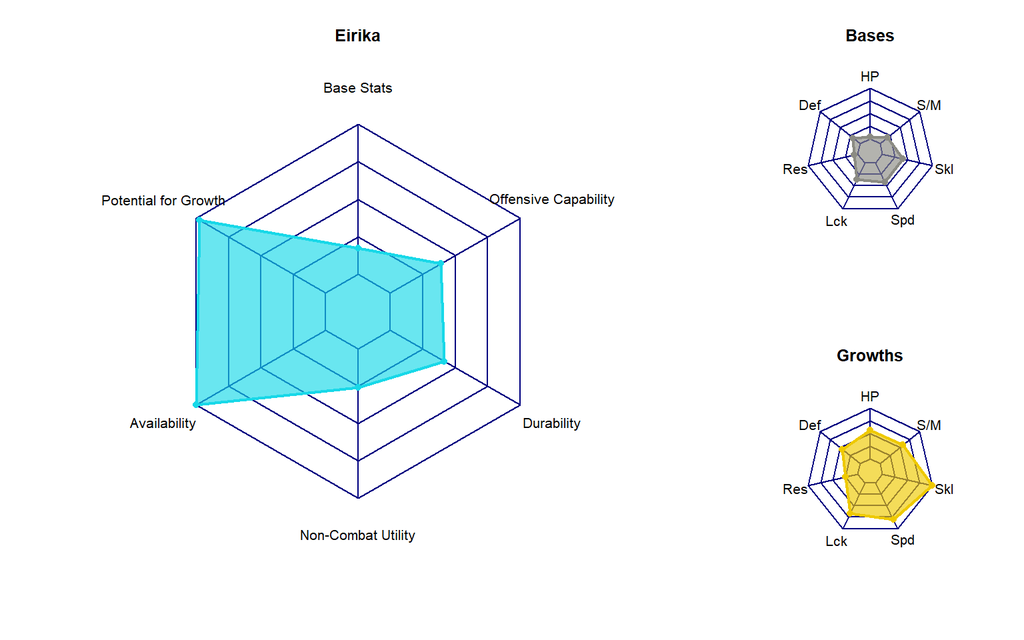

## Ephriam

The prince of Renais. He is a man of great honor and bravery.

[figure not shown]

## Seth

A young commander of Renais. He’s calm, composed, and skilled.

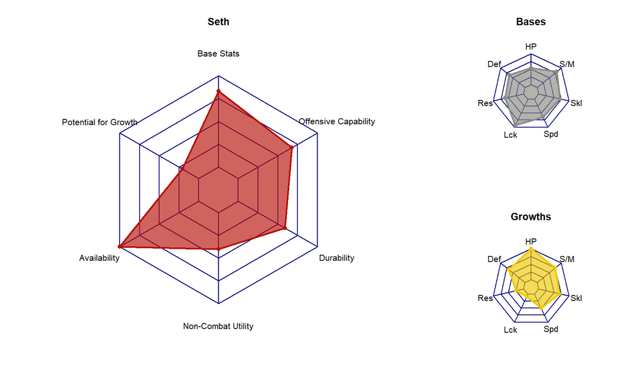

## Colm

A childhood friend of Neimi who hails from Renais. He can be snide.

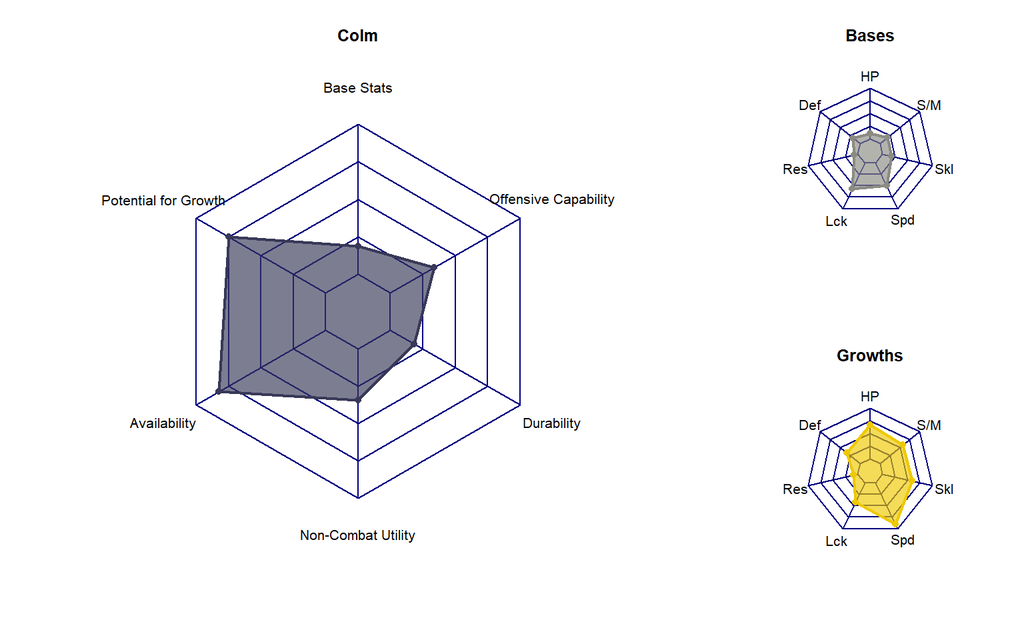

## Tethys

A beautiful and charming dancer from Jehanna.

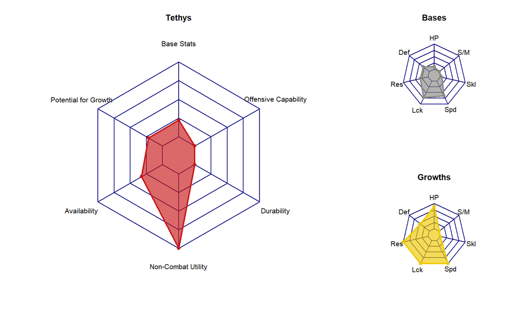

# Early Game

## Franz

An earnest and compassionate cavalier from Renais.

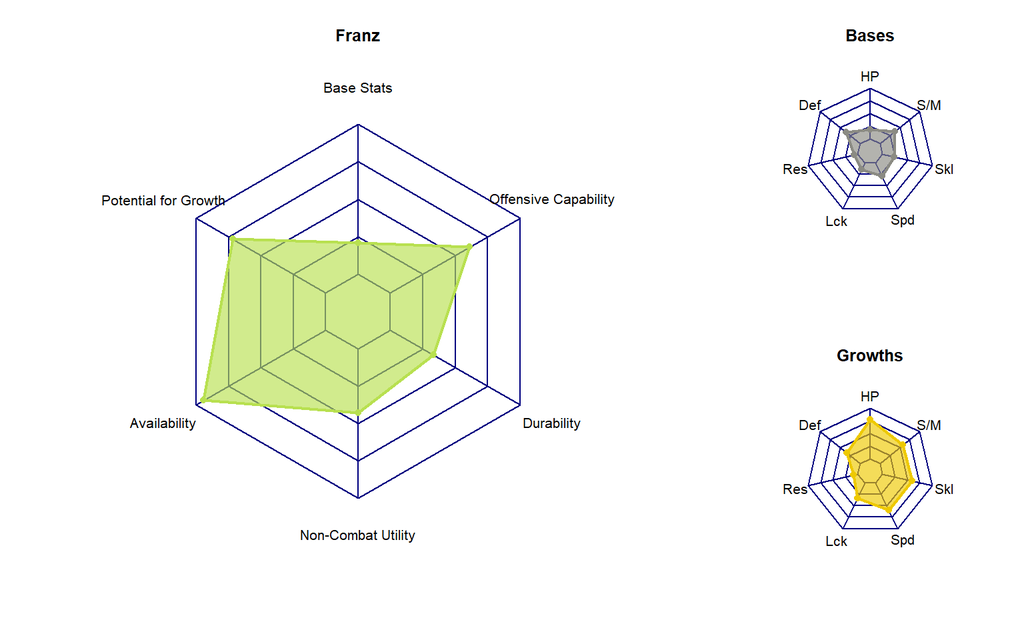

## Gilliam

An armored knight of Frelia. He’s quiet yet dependable.

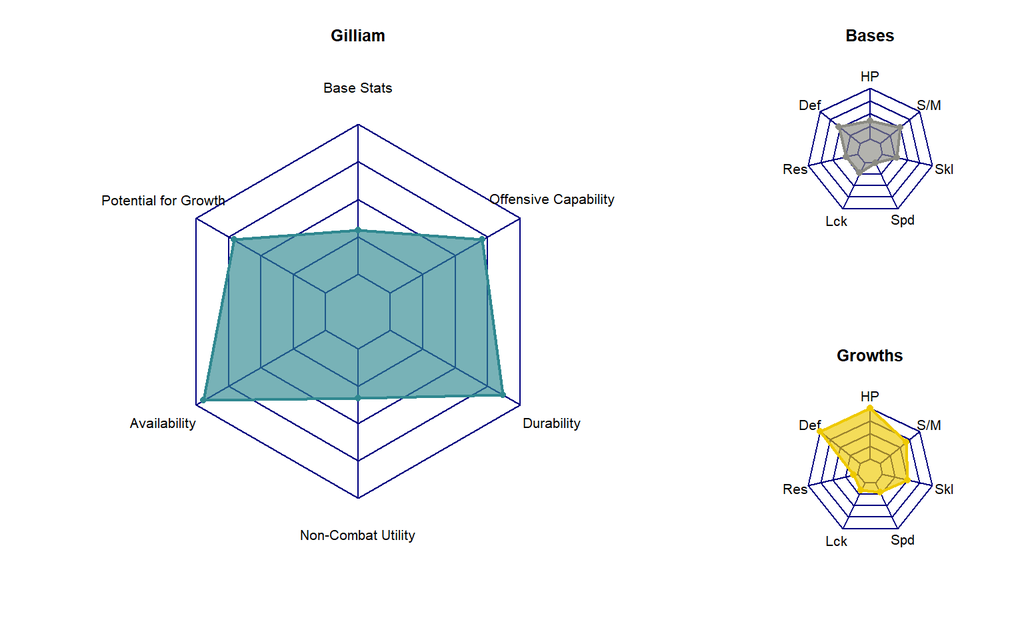

## Moulder

A mature priest of Frelia. He’s gentle and reassuring.

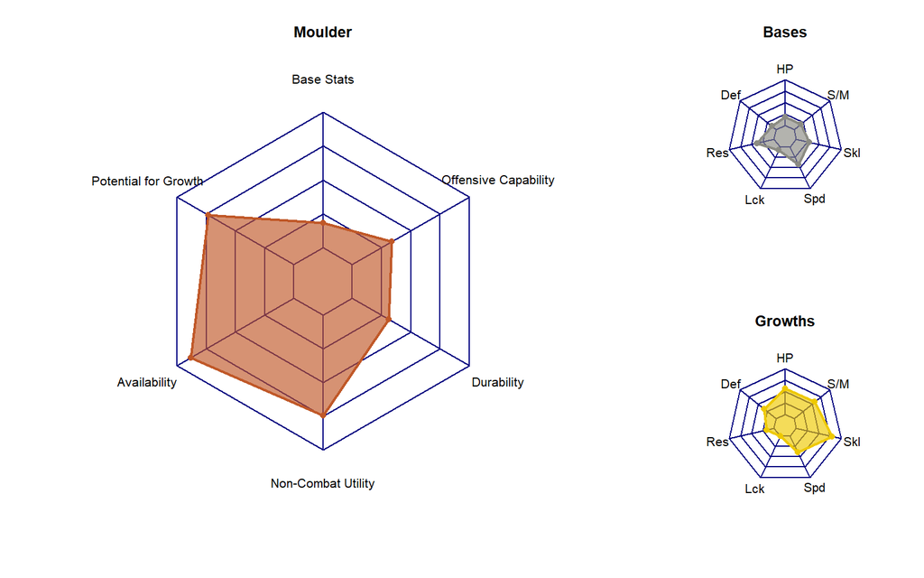

## Vanessa

A sincere, honest, and honorable pegasus knight of Frelia.

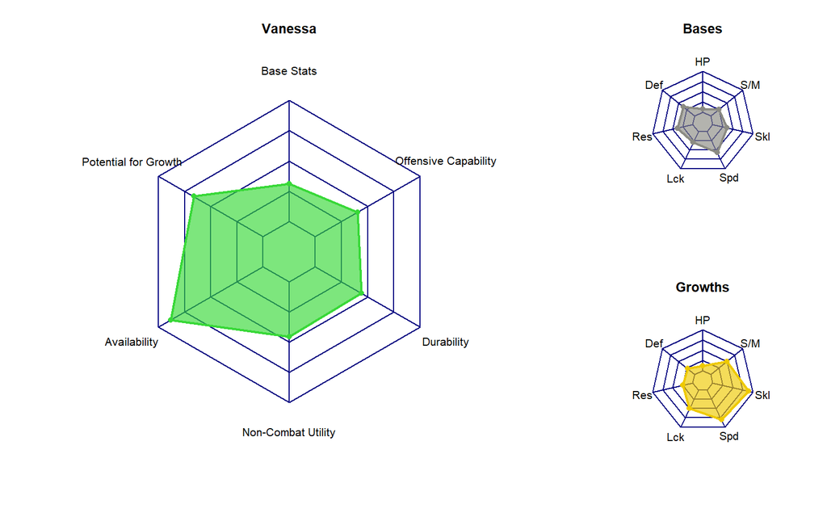

## Garcia

A villager from Renais. He was once a feared military leader.

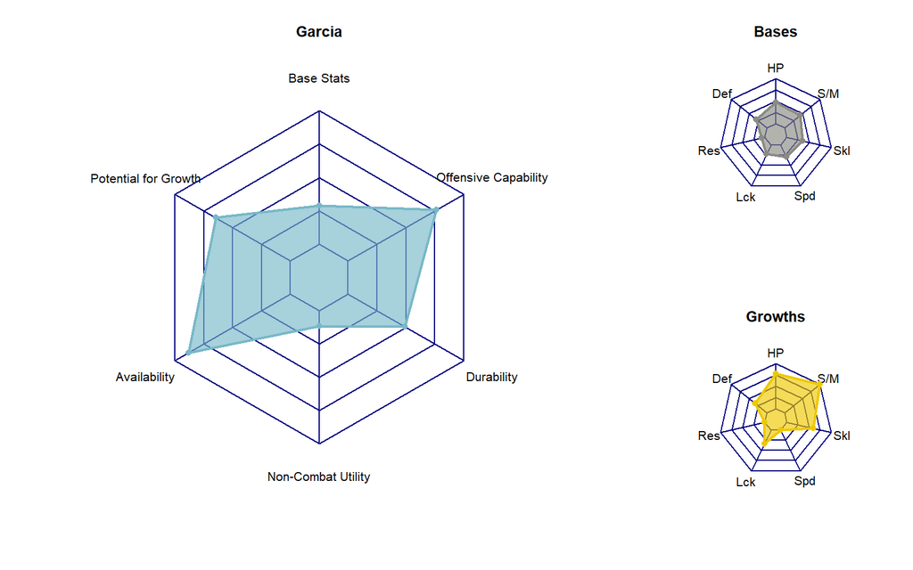

## Ross

A young villager. He longs to be a warrior, like his father.

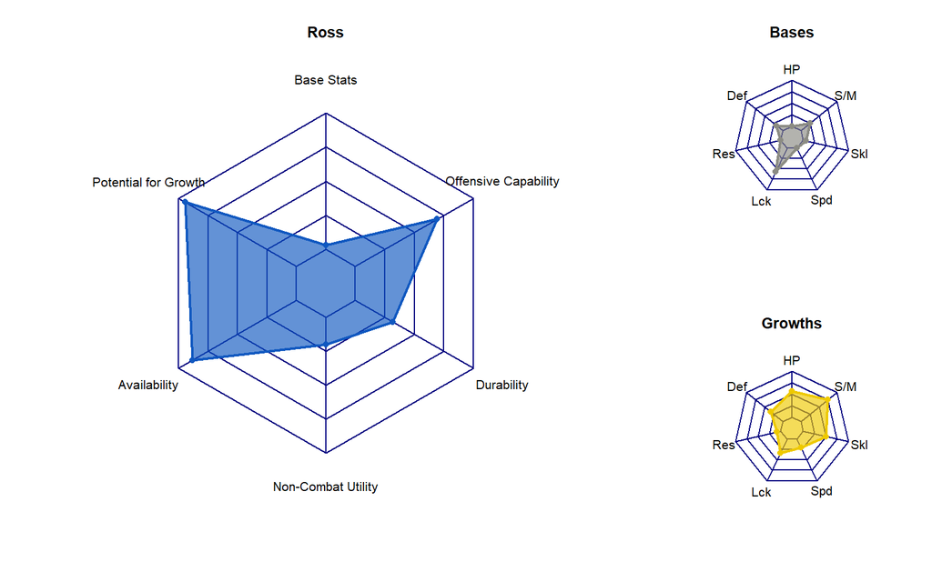

## Artur

A young monk from Renais. He is a very forthright and pious man.

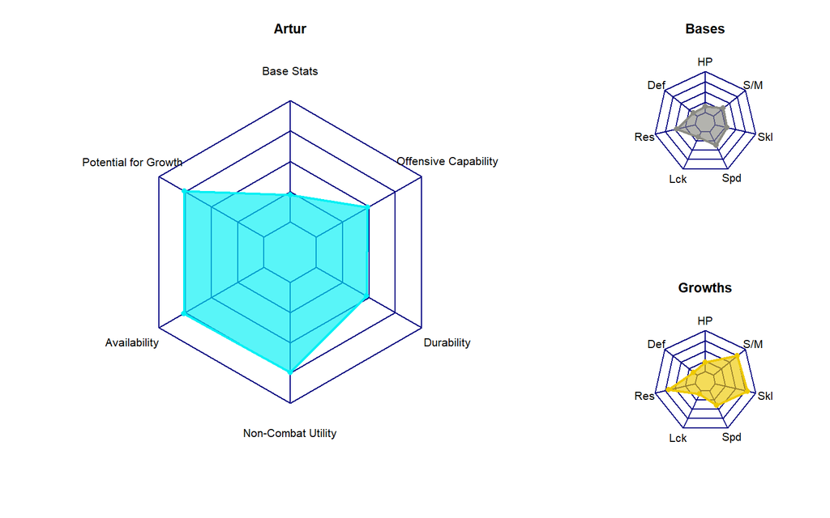

## Lute

A young mage of Renais. She believes she is a prodigy.

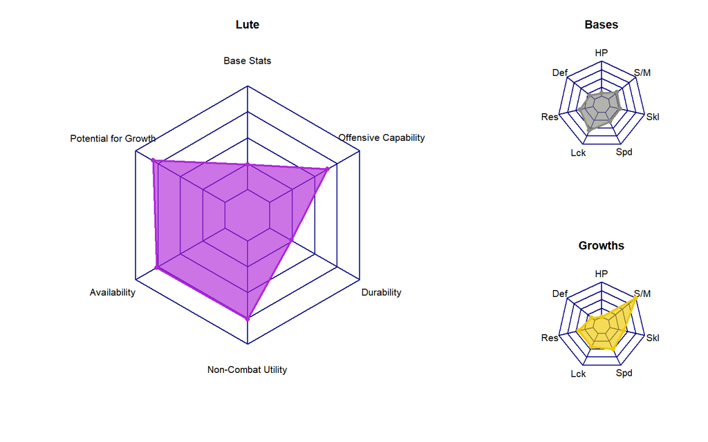

# Power Units

## Kyle

A steadfast and honorable cavalier in sworn service to Renais.

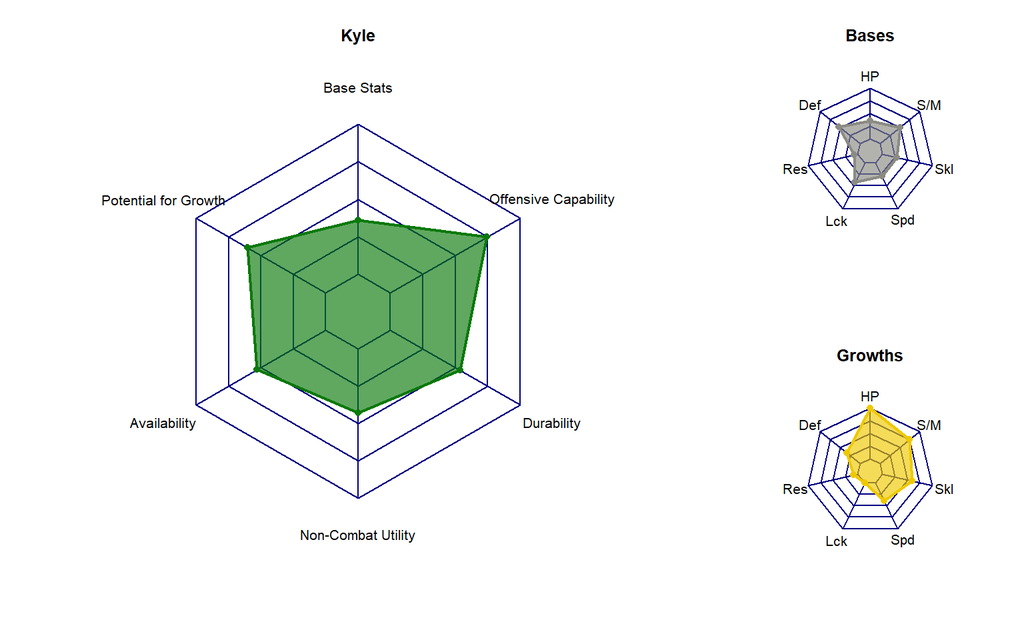

## Gerik

A mercenary leader from Jehanna. He’s better known as the Desert Tiger.

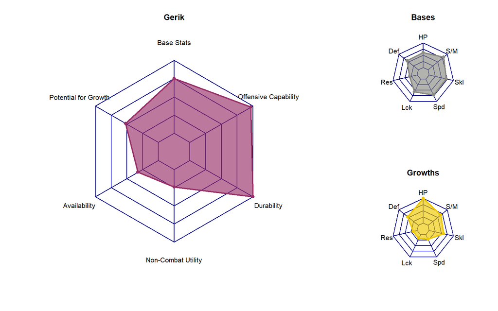

## Duessel

A courageous general in Grado’s army. He’s better known as Obsidian.

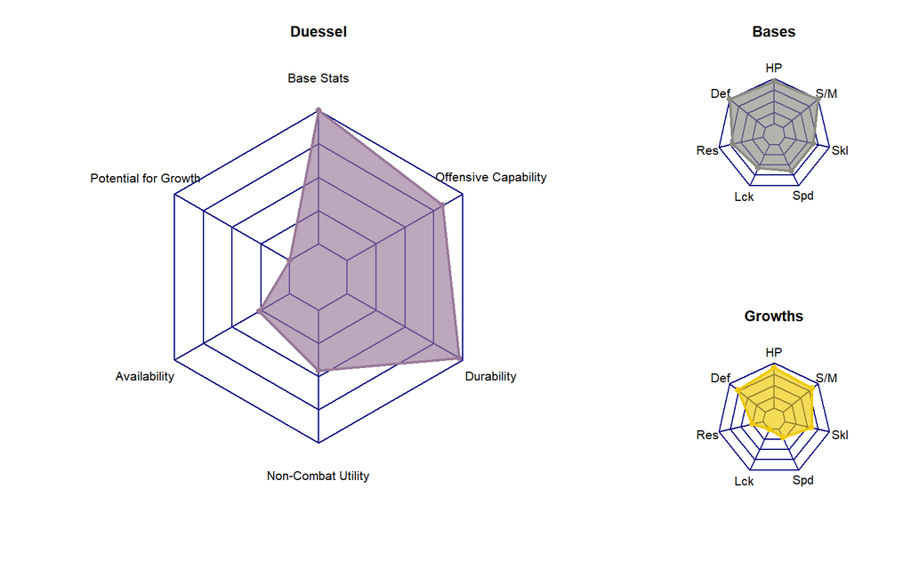

## Saleh

A sage from the village Caer Pelyn. He’s Ewan’s solemn, but kind, teacher.

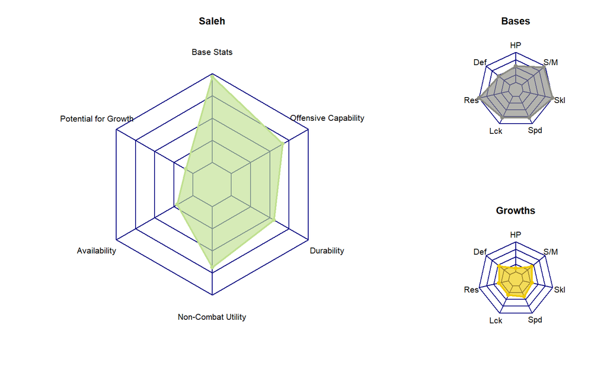

# Ok Units

## Natasha

A beautiful cleric from the Grado Empire. She’s graceful and serious.

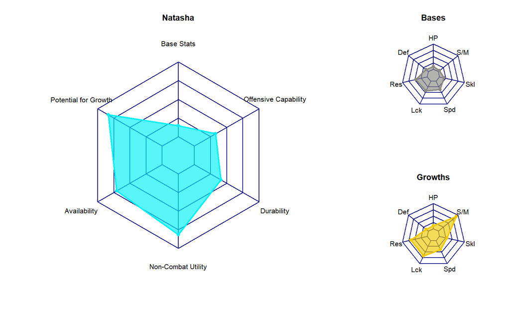

## Joshua

A wandering swordsman from Jehanna. He loves to gamble.

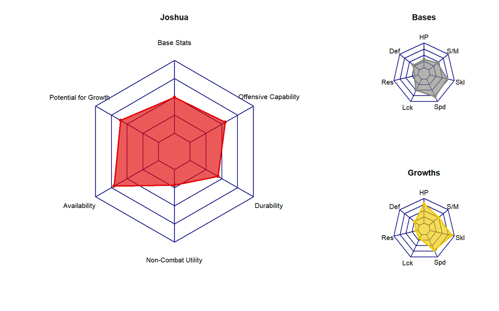

## LArachel

A young woman from Rausten. She fights for justice and order.

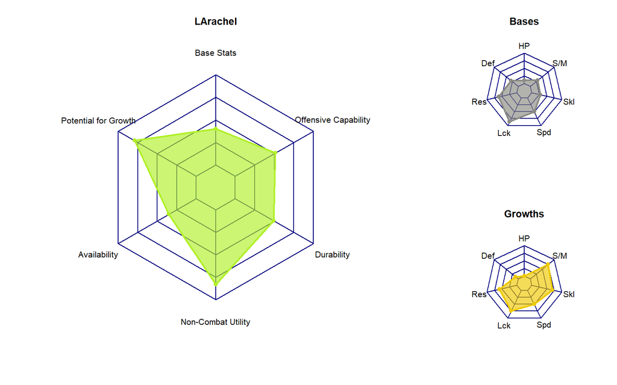

## Innes

The prince of Frelia. He’s brash and arrogant, but good at heart.

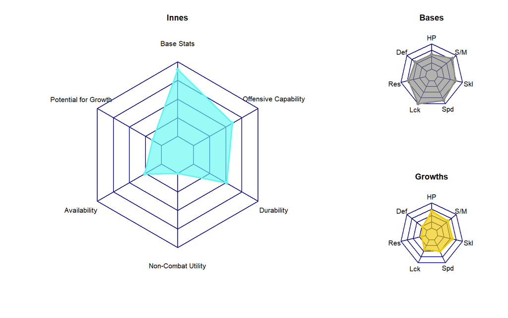

## Tana

A young lady of Frelia. She is both cheery and sociable.

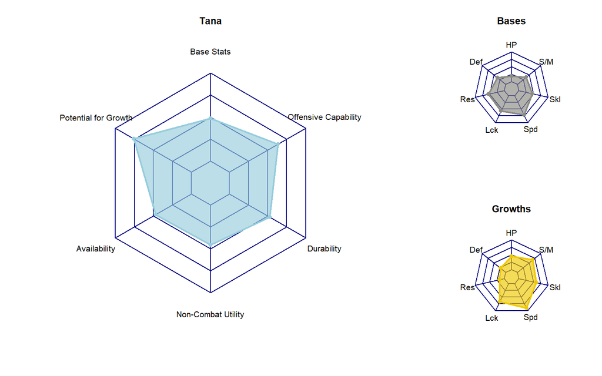

## Cormag

A wyvern knight of Grado. A gentle man, but a ferocious warrior.

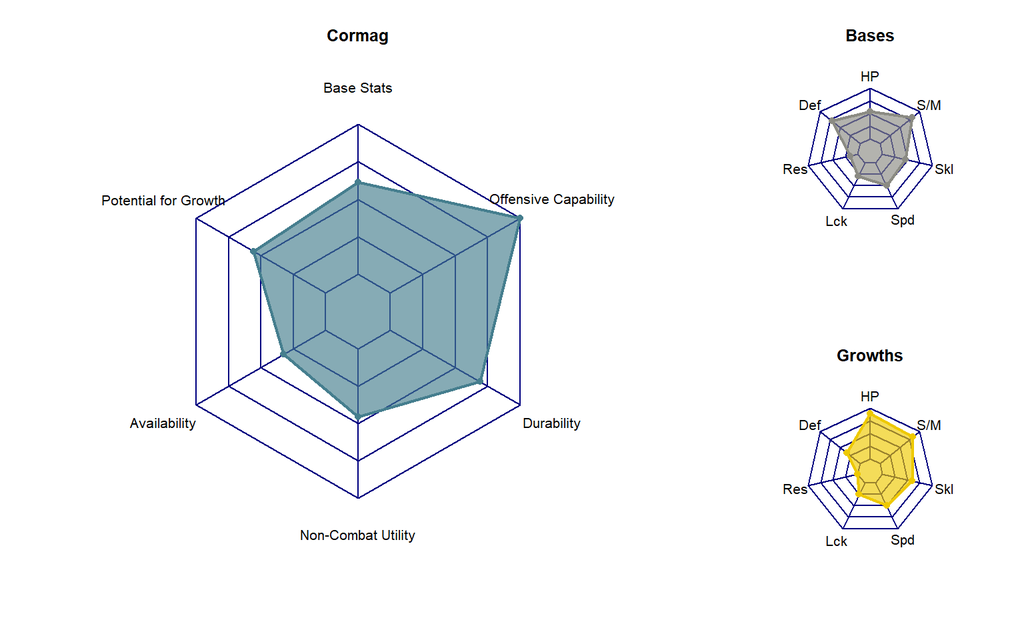

## Knoll

One of Grado’s royal mages. He knows the riddle of the Dark Stone.

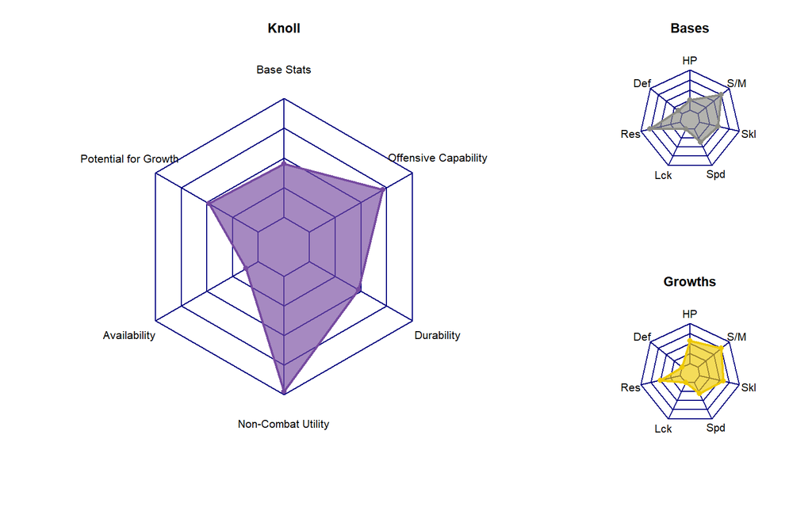

## Myrrh

A young, pure-hearted girl from Darkling Woods. She tends to be shy.

[figure not shown]

# UH-OH

## Neimi

A childhood friend of Colm who hails from Renais. She cries a lot.

[figure not shown]

## Forde

A cavalier from Renais. He is skilled, but reckless. He’s Franz’s brother.

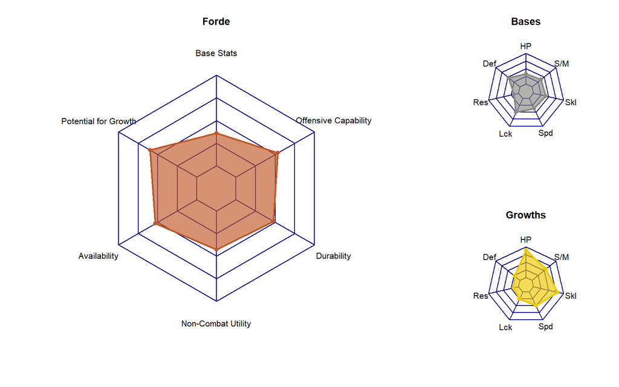

## Amelia

A young girl from a small village in Grado. She is honest and sincere.

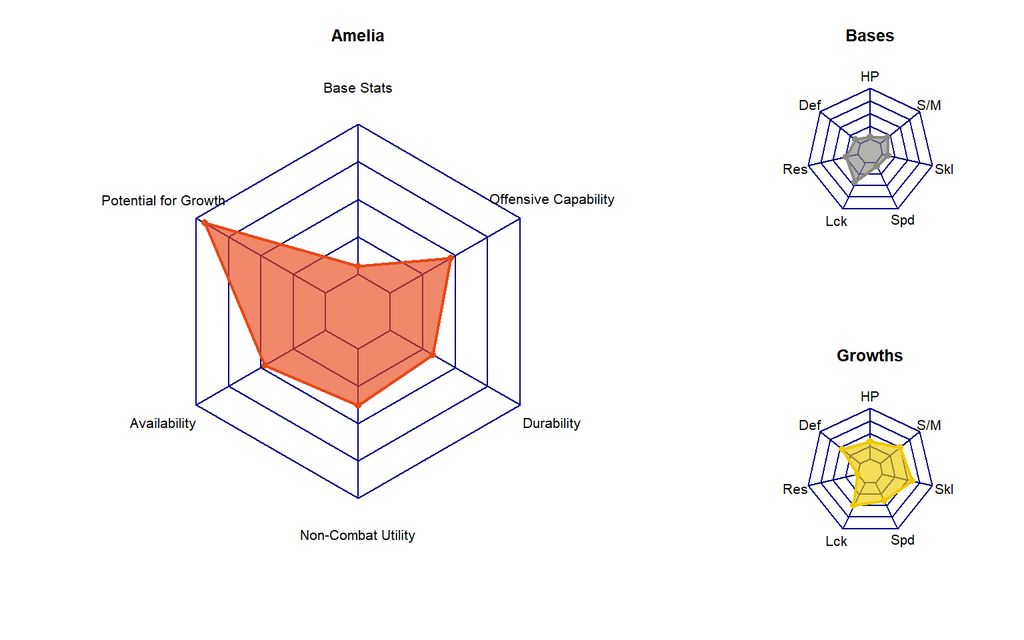

## Dozla

A berserker from Rausten. He’s a hearty man with a thirst for life.

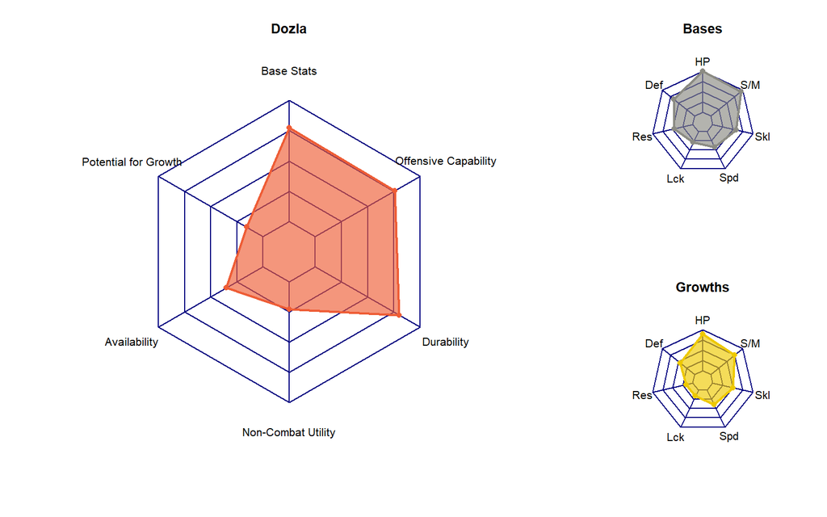

## Marisa

An aloof sword fighter from Jehanna. She’s known as the Crimson Flash.

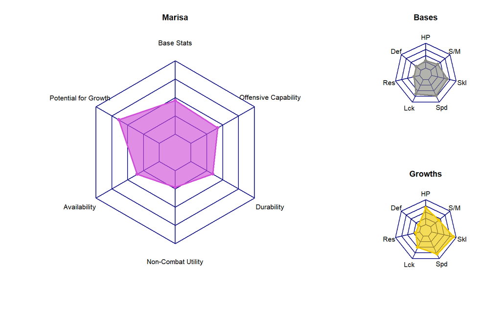